# CMSC422 Final Project : Predicting Salaries from Demographic Information

### Group Members

- Anthony Pechenov
- Gavin Mealy
- Ritika Sabharwal
- Matthew Ruyter
- Oladotun Oladimejij
- Introduction
  - Whats in the data
- Motivation
- Reading in Data
- Diversity of Data
  - Percentage of different Races
  - Percentage of different Sexes
  - Percentage of different WorkClasses
  - Percentage of different Native Countries
  - Percentage of different Highest Education Levels
- Cleaning Data
- Random Forests
  - Encoding
  - Confusion Matrix Random Forests
  - Importance of Features Random Forests.
  - Summary of Random Forests
  - Plotting Accuracy of Features with Low Diversity Individually
    - Sex vs. Accuracy
    - Race vs. Accuracy
    - Workclass vs. Accuracy
    - Native Country vs. Accuracy
- Process Data
- K-NN Classifier
- Perceptron Classifier
- Accounting for bias in the dataset
- Perceptron
- Gradient Boosting
  - Preprocessing
    - Combining similar data values
    - Encoding
    - Mode of each attribute/replacing missing data:
    - Set salary to be a binary variable
    - Observe the 5 characteristics with the top correlations to salary
    - Reducing skew in the data
  - Training a model
    - Tuning Hyperparameters
    - Update all the hyperparameters, and re-run the model
    - Analysis
    - ROC Curve
  - Plotting accuracy of Features with Low Diversity Individually
    - Sex vs. Accuracy
    - Race vs. Accuracy

## Introduction

According to White House Data, the average single-parent family has a budget of about $49,000 a year, which is roughly half the budget of the average married family with children. However, during the pandemic, the financial state of every household, and the economy in general. It's important to keep up with the economical state of the world, but without understanding what things were like it's hard to get a full perspective on the present.

For our project we will be primarily looking at US income data from 1994. Our interest is in seeing if we can predict the factors which contribute to a person's income being above or below 50k per year as these are the people who typically need the most help in the form of financial assistance. We also want to see if we can visualize income inequality in income to see if there are any specific groups of people most in need of financial aid.

```python
import pandas as pd
import numpy as np
import seaborn as sns
```

### What's in the data

- age: The age of an individual, this ranges from 17 to 90.
- workclass: The class of work to which an individual belongs.
- fnlwgt: The weight assigned to the combination of features (an estimate of how many people belong to this set of features).
- education: highest level of education.
- education-num: number of years the person was in school for.
- marital-status: category indicating marriage status of a person.
- occupation: profession of a person.
- relationship: relation of person to family.
- race: race of a person.
- sex: gender of a person.
- capital-gain: capital gained by a person.
- capital-loss: capital lost by a person.
- hours per week (hpw): hours per week that the person works.
- native-country: origin country of a person.

```python
data = pd.read_csv('Dataset.data', sep = ' ',header=None)
data.columns = ['age','workclass','fnlwgt','education','educational_num','marital_status','occupation','relationship','race','gender','capital_gain','capital_loss','hours_per_week','native_country','income']
data['workclass'] = data['workclass'].replace('?', 'Private')
data['occupation'] = data['occupation'].replace('?', 'Prof-specialty')
data['native_country'] = data['native_country'].replace('?', 'United-States')
data.head()
```

|  | age | workclass | fnlwgt | education | educational_num | marital_status | occupation | relationship | race | gender | capital_gain | capital_loss | hours_per_week | native_country | income |
| --- | --- | --- | --- | --- | --- | --- | --- | --- | --- | --- | --- | --- | --- | --- | --- |
| 0 | 25 | Private | 226802 | 11th | 7 | Never-married | Machine-op-inspct | Own-child | Black | Male | 0 | 0 | 40 | United-States | <=50K |
| 1 | 38 | Private | 89814 | HS-grad | 9 | Married-civ-spouse | Farming-fishing | Husband | White | Male | 0 | 0 | 50 | United-States | <=50K |
| 2 | 28 | Local-gov | 336951 | Assoc-acdm | 12 | Married-civ-spouse | Protective-serv | Husband | White | Male | 0 | 0 | 40 | United-States | >50K |
| 3 | 44 | Private | 160323 | Some-college | 10 | Married-civ-spouse | Machine-op-inspct | Husband | Black | Male | 7688 | 0 | 40 | United-States | >50K |
| 4 | 18 | Private | 103497 | Some-college | 10 | Never-married | Prof-specialty | Own-child | White | Female | 0 | 0 | 30 | United-States | <=50K |

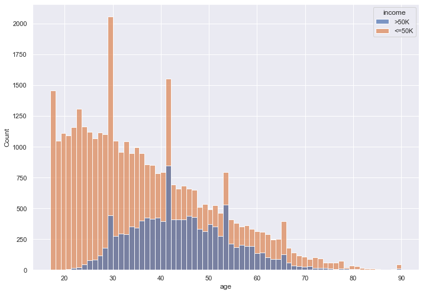

```python
sns.set(rc={'figure.figsize':(11.7,8.27)})
sns.histplot(data=data, x="age", hue="income", alpha=0.7, hue_order=['>50K','<=50K'])
```

Looking at our dataset we can see that a majority of our observations are making less than 50k dollars per year, in fact there's no age group where there are more people making $50k. Most of the data points are on the younger side of things as we progressively have less and less data. We don't see people making more than 50k until a bit past 20, and the greatest concentration of people making over 50k is approximately in their early to mid 40s. Until around their mid 30s there is a huge difference between the number below 50k and above 50k which evens out at later ages.

Creating these histograms is fairly easy using seaborn. If you want to try your own hand at making a histogram showing of a distribution between two variables you can get a pretty easy head start here: https://seaborn.pydata.org/tutorial/distributions.html

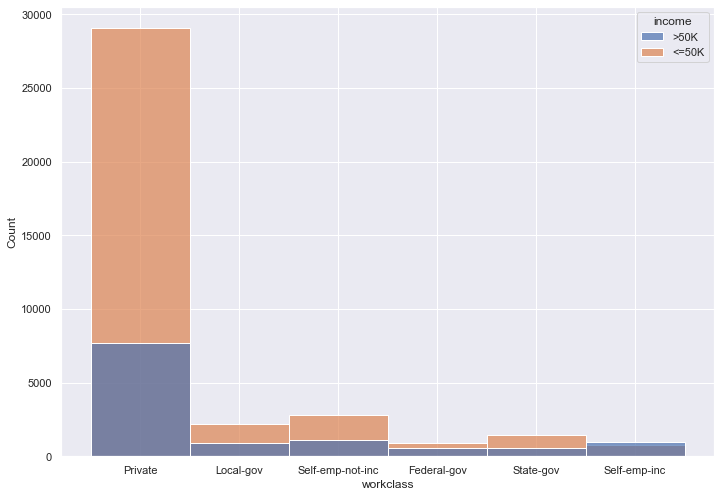

```python
sns.set(rc={'figure.figsize':(11.7,8.27)})
list =["Private","Local-gov","State-gov","Federal-gov","Self-emp-not-inc","Self-emp-inc"]
df2 = data[data.workclass.isin(list)]
sns.histplot(data=df2, x="workclass", hue="income", alpha=0.7, hue_order=['>50K','<=50K'])
```

There are a few things which draw attention. We see that the biggest source of employment is through privately owned businesses, noting that this bin excludes ownership positions. This category also seems to have the biggest divide between people earning more or less than 50k. This is expected as a lot of privately owned businesses pay minimum wage. Moving on to government positions we see that as we work our way up the divide between incomes becomes less and less, though so does the number of employees. We see that the distribution of pay is much more fair here. For self employment we see that in non incorporated businesses there is a fairly normal divide between earnings, but for incorporated businesses, we actually see that more people make over 50k per year than under. These people are owners which run their own businesses, so it would make sense that especially with more successful businesses that these people would be able to pay themselves more.

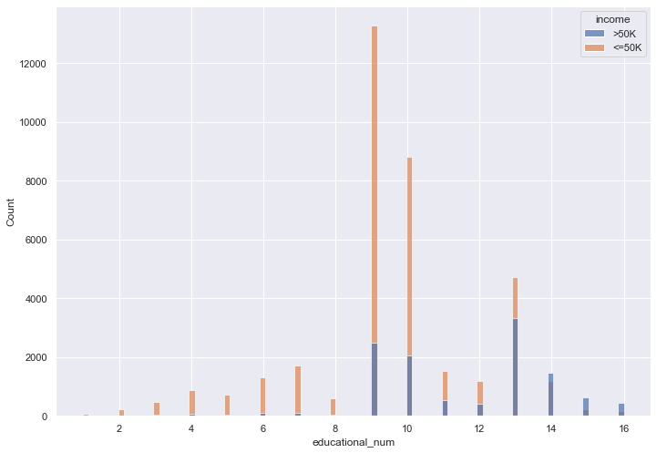

```python
sns.histplot(data=data, x="educational_num", hue="income", alpha=0.7, hue_order=['>50K','<=50K'])
```

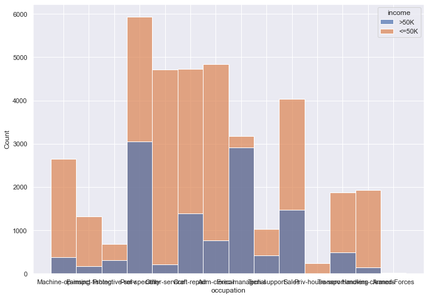

```python
sns.histplot(data=data, x="occupation", hue="income", alpha=0.7, hue_order=['>50K','<=50K'])
```

```python
data["occupation"].unique()
```

```
array(['Machine-op-inspct', 'Farming-fishing', 'Protective-serv',
       'Prof-specialty', 'Other-service', 'Craft-repair', 'Adm-clerical',
       'Exec-managerial', 'Tech-support', 'Sales', 'Priv-house-serv',
       'Transport-moving', 'Handlers-cleaners', 'Armed-Forces'],
      dtype=object)
```

We can see that there are a lot of variables for occupation, which is where we begin struggling with the dimensionality of the data. The issue here as seen in the graph above is that the amount of data is making it hard to visualize and draw conclusions from it. This often happens when there are lots of features, some of which are of similar nature. In order to combat this issue we will be performing some basic dimensionality reduction. We will do this by grouping together certain occupations under a joint banner.

Dealing with categorical variables is not always as easy as here, so it might help to read more about them if you try to work with a model of your own. For the grouping on this model I used: https://www.analyticsvidhya.com/blog/2015/11/easy-methods-deal-categorical-variables-predictive-modeling/, consulting the combine levels section on how to reduce redundancy.

```python
data["job"] = "Other"
for i, row in (data.iterrows()):
    if str(data.at[i,'occupation']) == 'Machine-op-inspct':
        data.at[i,'job'] = "BlueCollar"
    if str(data.at[i,'occupation']) == 'Farming-fishing':
        data.at[i,'job'] = "BlueCollar"
    if str(data.at[i,'occupation']) == 'Protective-serv':
        data.at[i,'job'] = "Service"
    if str(data.at[i,'occupation']) == 'Prof-specialty':
        data.at[i,'job'] = "Professional"
    if str(data.at[i,'occupation']) == 'Other-service':
        data.at[i,'job'] = "Service"
    if str(data.at[i,'occupation']) == 'Craft-repair':
        data.at[i,'job'] = "BlueCollar"
    if str(data.at[i,'occupation']) == 'Adm-clerical':
        data.at[i,'job'] = "WhiteCollar"
    if str(data.at[i,'occupation']) == 'Exec-managerial':
        data.at[i,'job'] = "WhiteCollar"
    if str(data.at[i,'occupation']) == 'Tech-support':
        data.at[i,'job'] = "Service"
    if str(data.at[i,'occupation']) == 'Sales':
        data.at[i,'job'] = "Sales"
    if str(data.at[i,'occupation']) == 'Priv-house-serv':
        data.at[i,'job'] = "Service"
    if str(data.at[i,'occupation']) == 'Transport-moving':
        data.at[i,'job'] = "BlueCollar"
    if str(data.at[i,'occupation']) == 'Handlers-cleaners':
        data.at[i,'job'] = "BlueCollar"
    if str(data.at[i,'occupation']) == 'Armed-Forces':
        data.at[i,'job'] = "Service"
```

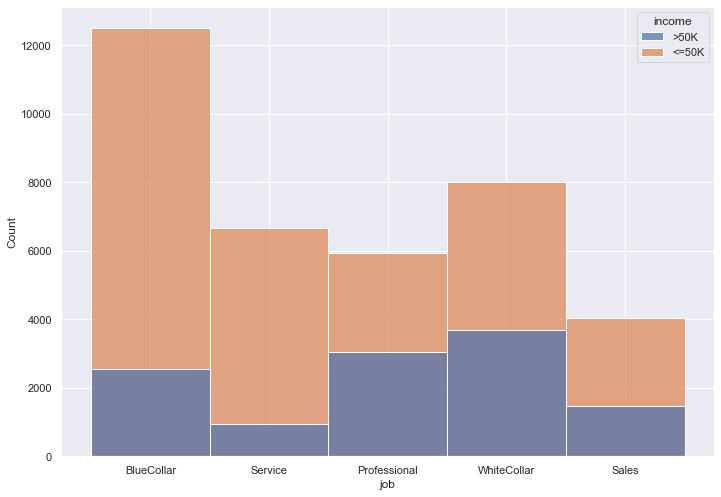

```python
sns.histplot(data=data, x="job", hue="income", alpha=0.7, hue_order=['>50K','<=50K'])
```

```python
import numpy as np
import pandas as pd
import seaborn as sns
from sklearn import tree
from sklearn.metrics import confusion_matrix, ConfusionMatrixDisplay, accuracy_score, classification_report, precision_score,recall_score, f1_score
import matplotlib.pyplot as plt
from sklearn.preprocessing import LabelEncoder, StandardScaler
from sklearn.model_selection import train_test_split
import warnings
warnings.filterwarnings("ignore")
```

## Motivation

What are we trying to learn here? I think most of us can think of societal factors that contribute to the income gap in our society. We want to learn is what factors contribute to this in our data. Results could aid in figuring out which groups to assist in efforts to balance out these income discrepancies. Personally I wanted to know if factors like race and gender and years of education would impact a person’s income. We want to know if the data supports our theories, if not, then what does it actually say, and can we trust these results. If so, can we also visualize these results?

## Reading in Data

```python
f_data = open('Dataset.data', 'r')
data_raw = np.array(f_data.readlines())
f_data.close()
```

```python
df = pd.read_csv('Dataset.data', sep = ' ', header = None)
```

```python
original_data = df.set_axis(['age', 'workclass', 'fnlwgt', 'highest_education', 'years_educated', 'marital_status', 'occupation','relationship', 'race', 'sex', 'capital_gain', 'capital_loss', 'hpw', 'native_country', 'salary'], axis=1)
```

```python
original_data.head()
```

|  | age | workclass | fnlwgt | highest_education | years_educated | marital_status | occupation | relationship | race | sex | capital_gain | capital_loss | hpw | native_country | salary |
| --- | --- | --- | --- | --- | --- | --- | --- | --- | --- | --- | --- | --- | --- | --- | --- |
| 0 | 25 | Private | 226802 | 11th | 7 | Never-married | Machine-op-inspct | Own-child | Black | Male | 0 | 0 | 40 | United-States | <=50K |
| 1 | 38 | Private | 89814 | HS-grad | 9 | Married-civ-spouse | Farming-fishing | Husband | White | Male | 0 | 0 | 50 | United-States | <=50K |
| 2 | 28 | Local-gov | 336951 | Assoc-acdm | 12 | Married-civ-spouse | Protective-serv | Husband | White | Male | 0 | 0 | 40 | United-States | >50K |
| 3 | 44 | Private | 160323 | Some-college | 10 | Married-civ-spouse | Machine-op-inspct | Husband | Black | Male | 7688 | 0 | 40 | United-States | >50K |
| 4 | 18 | ? | 103497 | Some-college | 10 | Never-married | ? | Own-child | White | Female | 0 | 0 | 30 | United-States | <=50K |

## Diversity of Data

```python
colors = sns.color_palette('pastel')[0:5]
```

### Percentage of different Races

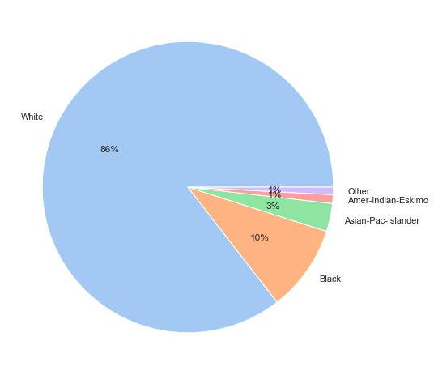

```python
#create pie chart
plt.pie(original_data.race.value_counts(), labels = original_data.race.value_counts().index , colors = colors, autopct='%.0f%%')
plt.show()
```

## Percentage of different Sexes

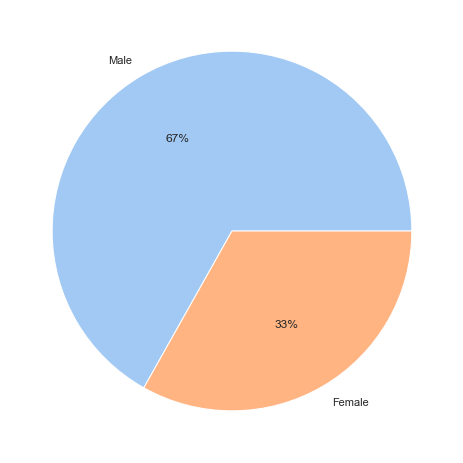

```python
plt.pie(original_data.sex.value_counts(), labels = original_data.sex.value_counts().index , colors = colors, autopct='%.0f%%')
plt.show()
```

## Percentage of different Workclasses

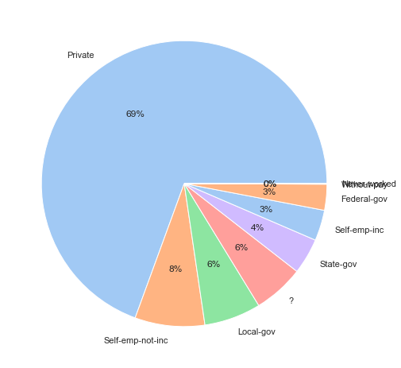

```python
plt.pie(original_data.workclass.value_counts() , labels = original_data.workclass.value_counts().index , colors = colors, autopct='%.0f%%')
plt.show()
```

## Percentage of different Native Countries

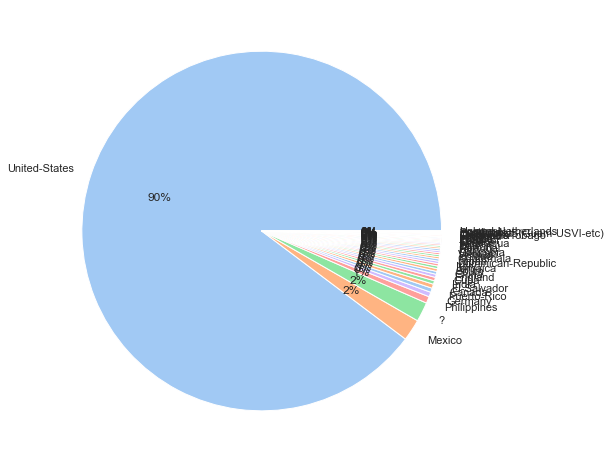

```python
plt.pie(original_data.native_country.value_counts() , labels = original_data.native_country.value_counts().index , colors = colors, autopct='%.0f%%')
plt.show()
```

## Percentage of different Highest Education Levels

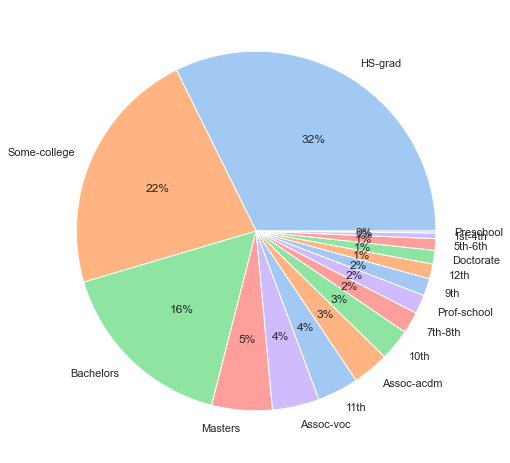

```python
plt.pie(original_data.highest_education.value_counts() , labels = original_data.highest_education.value_counts().index , colors = colors, autopct='%.0f%%')
plt.show()
```

## Cleaning Data

```python
original_data['workclass'] = original_data['workclass'].replace('?', 'Private')
original_data['occupation'] = original_data['occupation'].replace('?', 'Prof-specialty')
original_data['native_country'] = original_data['native_country'].replace('?', 'United-States')

original_data['salary'] = original_data['salary'].replace({'<=50K':0, '>50K':1})
original_data = original_data.drop('fnlwgt', axis=1)
```

## Random Forests

Using Sklearn , We ran Random forest, A supervised Machine Learning Algorithm that builds decision trees on different samples and takes their majority vote for classification and average in case of regression. On this model we trained on a 80-20 split. And we received an accuracy of about 86%

```python
data = original_data.copy(deep=True)
```

### Encoding

We also encode our qualitative data into numerical values for our models to be able to learn from all features.

```python
le = LabelEncoder()
data['workclass'] = le.fit_transform(data['workclass'])
data['highest_education'] = le.fit_transform(data['highest_education'])
data['marital_status'] = le.fit_transform(data['marital_status'])
data['occupation'] = le.fit_transform(data['occupation'])
data['relationship'] = le.fit_transform(data['relationship'])
data['race'] = le.fit_transform(data['race'])
data['sex'] = le.fit_transform(data['sex'])
data['native_country'] = le.fit_transform(data['native_country'])
```

```python
sc = StandardScaler()
data_x = data.drop('salary', axis = 'columns')
y = data['salary']

scaled_data_x = sc.fit_transform(data_x)
x = pd.DataFrame(scaled_data_x, columns = data_x.columns)
```

```python
X_train, X_test, y_train, y_test = train_test_split(
     x, y, test_size=0.20, random_state=42)
```

```python
from sklearn.ensemble import RandomForestClassifier
forest = RandomForestClassifier()
forest = forest.fit(X_train, y_train)
```

```python
y_pred = forest.predict(X_test)
```

```python
print(confusion_matrix(y_test, y_pred))
print("\n\nAccuracy:{:,.2f}%".format(accuracy_score(y_test, y_pred)*100))
print("Precision:{:,.2f}%".format(precision_score(y_test, y_pred)*100))
print("Recall:{:,.2f}%".format(recall_score(y_test, y_pred)*100))
print("F1-Score:{:,.2f}%".format(f1_score(y_test, y_pred)*100))
```

```
[[6889  590]
 [ 824 1466]]


Accuracy:85.53%
Precision:71.30%
Recall:64.02%
F1-Score:67.46%
```

### Confusion Matrix Random Forests

This showed us where the Random Forests model gets confused. Looking at the matrix, had a significant amount of false negatives though the significance of false positive may be negligble.

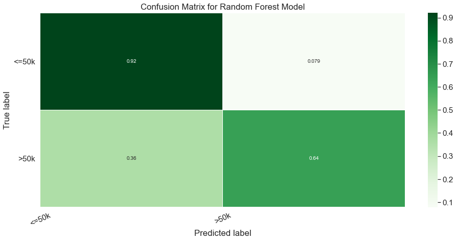

```python
matrix = confusion_matrix(y_test, y_pred)
matrix = matrix.astype('float') / matrix.sum(axis=1)[:, np.newaxis]

# Build the plot
plt.figure(figsize=(16,7))
sns.set(font_scale=1.4)
sns.heatmap(matrix, annot=True, annot_kws={'size':10},
            cmap=plt.cm.Greens, linewidths=0.2)

# Add labels to the plot
class_names = ['<=50k','>50k']
tick_marks = np.arange(len(class_names))
tick_marks2 = tick_marks + 0.5
plt.xticks(tick_marks, class_names, rotation=25)
plt.yticks(tick_marks2, class_names, rotation=0)
plt.xlabel('Predicted label')
plt.ylabel('True label')
plt.title('Confusion Matrix for Random Forest Model')
plt.show()
```

## Importance of Features Random Forests

We calculated the top 5 most important features in this model. Which is displayed in the bar graph below utilizing, mean decrease in impurity. This calculates each feature importance as the sum over the number of splits that include the feature, proportional to the number of samples it splits. The top 5 most important features, excluding were: age, realationship to family,capital gain, hours worked per week (hpw), and number of years of education.

What surprised us were features such as work class,native country,education race, and gender were so small, so we decided to look at our data a bit more closely. That is why plotted the representation of these features above. All the features besides education did not vary in diversity of values in that feature. In response to such low diversity we want to look at groups with low diversity individually. We will plot the train and test accuracy of those groups.

```python
importances = forest.feature_importances_
std = np.std([tree.feature_importances_ for tree in forest.estimators_], axis=0)
```

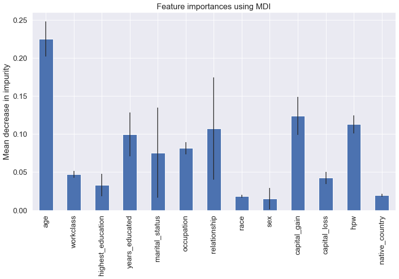

```python
forest_importances = pd.Series(importances, index=data_x.columns)

fig, ax = plt.subplots()
forest_importances.plot.bar(yerr=std, ax=ax)
ax.set_title("Feature importances using MDI")
ax.set_ylabel("Mean decrease in impurity")
fig.tight_layout()
```

### Summary of Random Forests

```python
train_pred = forest.predict(X_train)
test_pred = forest.predict(X_test)
test_acc = accuracy_score(y_test, test_pred)
train_acc = accuracy_score(y_train, train_pred)
print(forest)
print("Training data accuracy ", accuracy_score(y_test, test_pred))
print("Test data accuracy ", accuracy_score(y_train, train_pred))
print(classification_report(y_test, test_pred))
print(confusion_matrix(y_test, test_pred))
print('###########################################')
```

[output not shown]

### Plotting Accuracy of Features with Low Diversity Individually

Below we created a function 'plotAccuracyforFeature' which takes in the name of the feature in our dataframe and divides the data by the difference in value of that feature. trains the data on each instances and determines the traing accuracy and test accuracy then plots the difference between each unique value in that feature.

```python
def plotAccuracyforFeature(feature):
    feature_dfs = {}
    for feat in original_data[feature].unique():
        feature_dfs[feat] = (original_data.loc[original_data[feature] == feat])

    for feat in feature_dfs.keys():
        feature_dfs[feat]['workclass'] = le.fit_transform(feature_dfs[feat]['workclass'])
        feature_dfs[feat]['highest_education'] = le.fit_transform(feature_dfs[feat]['highest_education'])
        feature_dfs[feat]['marital_status'] = le.fit_transform(feature_dfs[feat]['marital_status'])
        feature_dfs[feat]['occupation'] = le.fit_transform(feature_dfs[feat]['occupation'])
        feature_dfs[feat]['relationship'] = le.fit_transform(feature_dfs[feat]['relationship'])
        feature_dfs[feat]['sex'] = le.fit_transform(feature_dfs[feat]['sex'])
        feature_dfs[feat]['race'] = le.fit_transform(feature_dfs[feat]['race'])
        feature_dfs[feat]['native_country'] = le.fit_transform(feature_dfs[feat]['native_country'])

        feature_dfs[feat] = feature_dfs[feat].drop(feature, axis=1)


    accuracy = {}
    for feat in feature_dfs.keys():
        sc = StandardScaler()
        data_x = feature_dfs[feat].drop('salary', axis = 'columns')

        y = feature_dfs[feat]['salary']

        scaled_data_x = sc.fit_transform(data_x)
        x = pd.DataFrame(scaled_data_x, columns = data_x.columns)


        if x.shape[0] == 1:
            X_train = X_test = x
            y_train =  y_test = y
        else:
            X_train, X_test, y_train, y_test = train_test_split(
             x, y, test_size=0.20, random_state=42)

        forest = RandomForestClassifier()
        forest = forest.fit(X_train, y_train)

        train_pred = forest.predict(X_train)
        test_pred = forest.predict(X_test)
        test_acc = accuracy_score(y_test, test_pred)
        train_acc = accuracy_score(y_train, train_pred)

        accuracy[feat] = {'trainAcc': float(train_acc), 'testAcc': float(test_acc)}


    feat_accuracy_df = []
    for key in accuracy.keys():
        tmp = [key, accuracy[key]['trainAcc'],accuracy[key]['testAcc']]
        feat_accuracy_df.append(tmp)

    feat_accuracy_df = np.array(feat_accuracy_df)
    feat_accuracy_df = pd.DataFrame(feat_accuracy_df, columns=[feature,'TrainAccuracy','TestAccuracy'])
    feat_accuracy_df['TrainAccuracy'] = feat_accuracy_df['TrainAccuracy'].astype(float)
    feat_accuracy_df['TestAccuracy'] = feat_accuracy_df['TestAccuracy'].astype(float)
    #race_accuracy_df

    X_axis = np.arange(len(feat_accuracy_df[feature]))
    plt.rcParams["figure.figsize"] = (20,10)
    bar1 = plt.bar(X_axis, (feat_accuracy_df['TrainAccuracy']), width=0.50, color='b', align='center')
    bar2 = plt.bar(X_axis+0.4, (feat_accuracy_df['TestAccuracy']), width=0.50, color='g', align='center')

    plt.xticks(X_axis, feat_accuracy_df[feature])
    plt.xlabel(feature)
    plt.ylabel('Accuracy')
    plt.title("{featName} Vs Accuracy on Random Forest".format(featName=feature))
    plt.legend( (bar1, bar2), ('Training Accuracy', 'Test Accuracy') )

    if len(feat_accuracy_df[feature]) >= 10:
        plt.xticks(rotation=90)

    plt.show()
```

### Sex vs. Accuracy

Overall when the data only included females it performed better on the test data than the whole data but when the data only included males it performed worst than the overall data, but the trainig data accuarcy between all three did not very that much

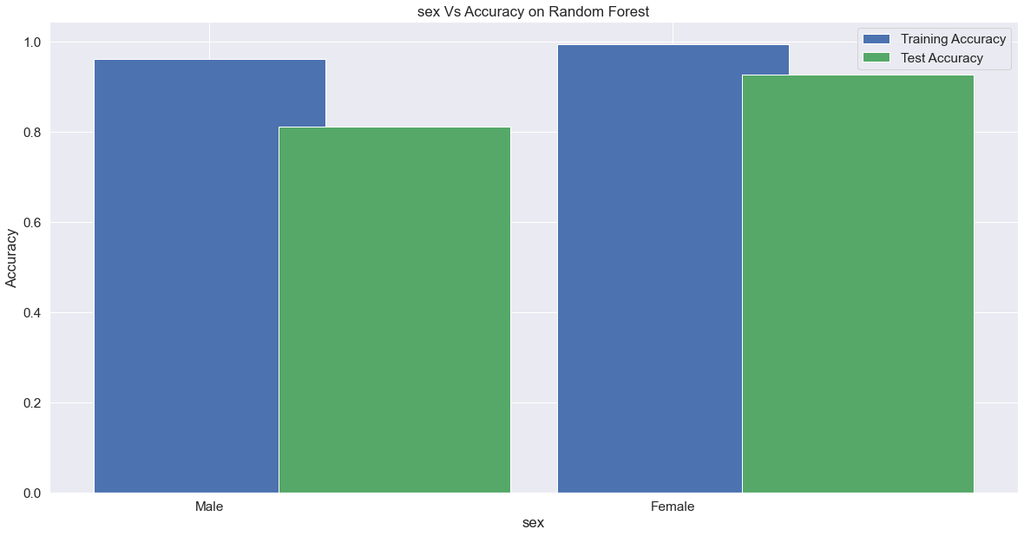

```python
plotAccuracyforFeature('sex')
```

### Race vs. Accuracy

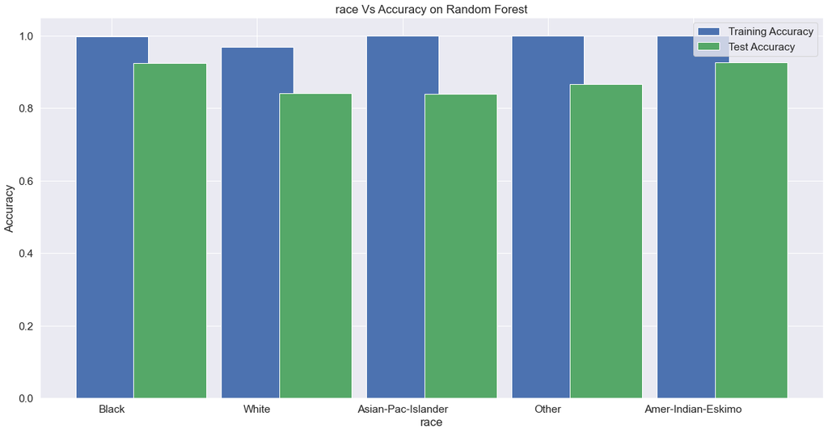

```python
plotAccuracyforFeature('race')
```

### Workclass vs. Accuracy

Overall when the data with unique workclass values on test data performed worst than over all data except for without pay and neverworked probably due to the fact there were few examples, the training accuracy was 100% percent for each unique value because they were minimal examples there was overfitting.

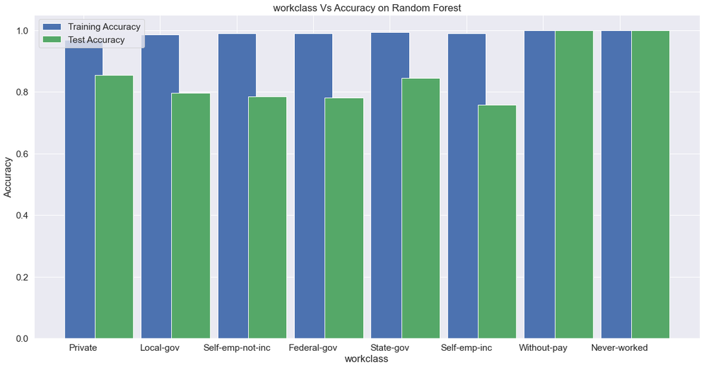

```python
plotAccuracyforFeature('workclass')
```

### Native Country vs. Accuracy

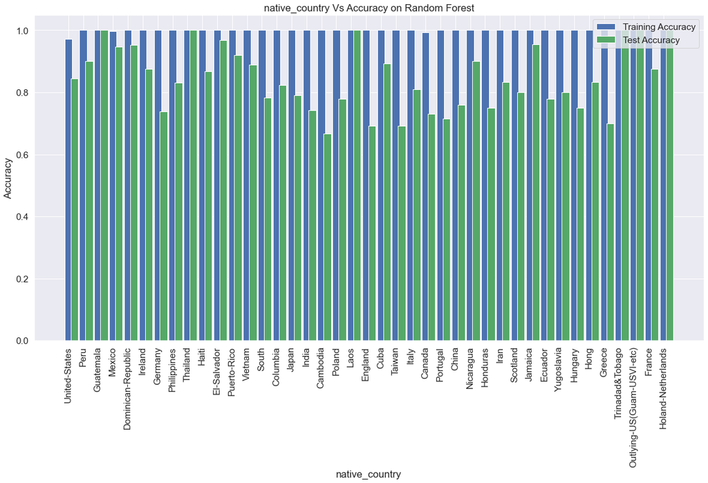

```python
plotAccuracyforFeature('native_country')
```

```python
import numpy as np
import pandas as pd
import matplotlib.pyplot as plt
import sklearn as sk
from sklearn.model_selection import train_test_split
```

The KNN and Perceptron Classifiers required the use of one hot encoding as its implementation was based of the ones we used in previous projects in class so we will be reading in our data again.

## Preprocess Data

Load dataset into a pandas dataframe.

```python
df = pd.read_csv('./Dataset.data', sep=' ', header=None)
df = df.set_axis(['age', 'workclass', 'fnlwgt', 'education', 'education_num', 'marital_status', 'occupation','relationship', 'race', 'sex', 'capital_gain', 'capital_loss', 'hpw', 'native_country', 'salary'], axis=1)
```

Replace missing data with the mode of that feature.

```python
df['workclass'] = df['workclass'].replace('?', 'Private')
df['occupation'] = df['occupation'].replace('?', 'Prof-specialty')
df['native_country'] = df['native_country'].replace('?', 'United-States')
df['salary'] = df['salary'].replace('<=50K', -1)
df['salary'] = df['salary'].replace('>50K', 1)
df = df.drop('fnlwgt', axis=1)
original_data = df
```

Perform one-hot encoding on categorical features.

```python
one_hot = pd.get_dummies(df['workclass'])
df = df.drop('workclass', axis=1)
df = df.join(one_hot)

one_hot = pd.get_dummies(df['education'])
df = df.drop('education', axis=1)
df = df.join(one_hot)

one_hot = pd.get_dummies(df['marital_status'])
df = df.drop('marital_status', axis=1)
df = df.join(one_hot)

one_hot = pd.get_dummies(df['occupation'])
df = df.drop('occupation', axis=1)
df = df.join(one_hot)

one_hot = pd.get_dummies(df['relationship'])
df = df.drop('relationship', axis=1)
df = df.join(one_hot)

one_hot = pd.get_dummies(df['race'])
df = df.drop('race', axis=1)
df = df.join(one_hot)

one_hot = pd.get_dummies(df['sex'])
df = df.drop('sex', axis=1)
df = df.join(one_hot)

one_hot = pd.get_dummies(df['native_country'])
df = df.drop('native_country', axis=1)
df = df.join(one_hot)
```

Save labels as a Y vector for training and testing classifiers.

```python
full_set = df
data_y = df['salary'].to_numpy()
df = df.drop('salary', axis=1)
```

Generate the numerical X matrix to be used for training and testing classifiers.

```python
data_x = df.to_numpy()
```

## K-NN Classifier

Separate into train/test set.

We're only using 30% of the data because of the time and computation it takes to do all the K-NN calculations.

```python
fraction_data = 0.3
fraction_train = 0.8

knn_data = full_set.sample(frac=fraction_data)
knn_y = knn_data['salary'].to_numpy()
knn_data.drop('salary', axis=1)
knn_x = knn_data.to_numpy()

knn_train_x, knn_test_x, knn_train_y, knn_test_y = sk.model_selection.train_test_split(knn_x, knn_y, test_size=(1 - fraction_train), shuffle=True)
```

Declare our K-NN classifier function. It also has the capability of classifying using Epsilon ball NN.

```python
def dist(x, y):
    return np.sqrt(np.dot(x-y,(x-y).T))

def knn_classify(k, train_x, train_y, X, epsilon):
    distances = []
    for i in range(0, len(train_x)):
        distances.append((dist(X, train_x[i]), train_y[i]))
    distances.sort()
    count = 0
    if epsilon:
        ptr = 0
        while ptr < len(distances) and distances[ptr][0] < k:
            if distances[ptr][1] == 1:
                count += 1
            else:
                count -= 1
            ptr += 1
        if ptr == 0:
            count = distances[0][1]
    else:
        for i in range(0, k):
            if distances[i][1] == 1:
                count += 1
            else:
                count -= 1
    return 1 if count >= 0 else -1
```

Now, let's try running the K-NN classifier on our dataset for different values of K and compare how it affects the accuracy of the model.

```python
neighbor_nums = [2, 3, 4, 5, 6, 7, 8, 9, 10, 15, 20]
count = 0
correct_frac = []
for n in neighbor_nums:
    preds = []
    for vec in knn_test_x:
        count += 1
        preds.append(knn_classify(n, knn_train_x, knn_train_y, vec, False))
    num_correct = sum(x == y for x,y in zip(knn_test_y, preds)) / len(knn_test_y)
    correct_frac.append(num_correct)
```

We can plot the accuracy of the K-NN model for the values of K we just calculated.

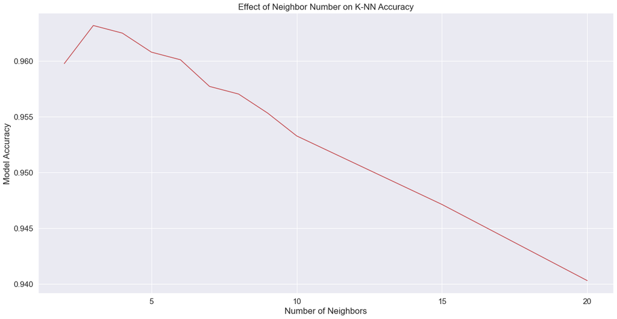

```python
plt.plot(neighbor_nums, correct_frac, 'r-')
plt.xlabel('Number of Neighbors')
plt.ylabel('Model Accuracy')
plt.title('Effect of Neighbor Number on K-NN Accuracy')
plt.locator_params(integer=True)
```

We can run a similar analysis on the data using an Epsilon ball nearest neighbors to see how the radius affects the accuracy of the model.

```python
epsilon_nums = [30, 50, 70, 100, 150, 200, 250, 300, 350, 500]
count = 0
ep_correct_frac = []
for e in epsilon_nums:
    preds = []
    for vec in knn_test_x:
        count += 1
        preds.append(knn_classify(e, knn_train_x, knn_train_y, vec, True))
    num_correct = sum(x == y for x,y in zip(knn_test_y, preds)) / len(knn_test_y)
    ep_correct_frac.append(num_correct)
```

Plotting these as well will show how large clusters are on average in the dataset.

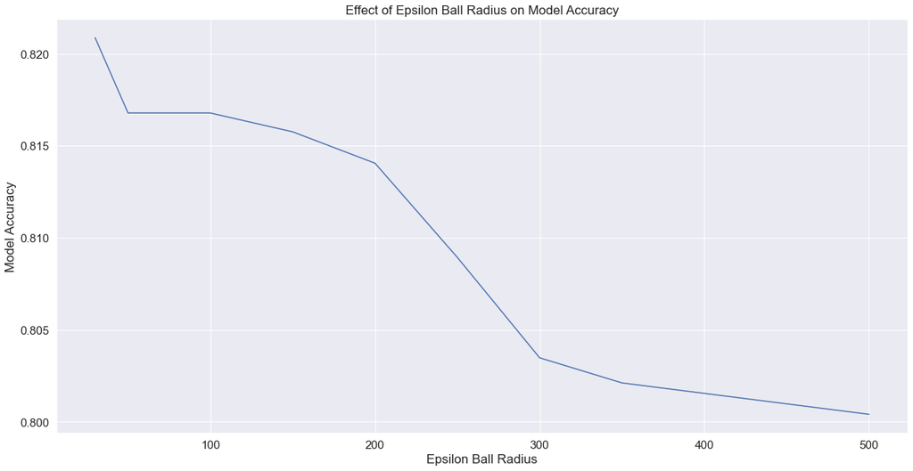

```python
plt.plot(epsilon_nums, ep_correct_frac, 'b-')
plt.xlabel('Epsilon Ball Radius')
plt.ylabel('Model Accuracy')
plt.title('Effect of Epsilon Ball Radius on Model Accuracy')
```

## Perceptron Classifier

Declare perceptron class

```python
class Perceptron():
    def __init__(self):
        self.weights = 0
        self.bias = 0
        self.updates = 0

    def predict(self, X):
        if self.updates == 0:
            return 0
        else:
            return np.dot(self.weights, X) + self.bias

    def train_example(self, X, Y):
        if Y * self.predict(X) <= 0:
            self.updates += 1
            self.weights = self.weights + (Y * X)
            self.bias = self.bias + Y
```

Make new train/test set

```python
train_x, test_x, train_y, test_y = train_test_split(data_x, data_y, test_size=0.2, shuffle=True)
```

Run the perceptron

```python
percep = Perceptron()

for i in range(0, len(train_x)):
    percep.train_example(train_x[i], train_y[i])

preds = []
for i in range(0, len(train_x)):
    preds.append(-1 if percep.predict(train_x[i]) < 0 else 1)

num_correct = sum(x == y for x,y in zip(train_y, preds))
print(' train accuracy = ', num_correct / len(train_y))

preds = []
for i in range(0, len(test_x)):
    preds.append(-1 if percep.predict(test_x[i]) < 0 else 1)

num_correct = sum(x == y for x,y in zip(test_y, preds))
print(' test accuracy = ', num_correct / len(test_y))
```

```
 train accuracy =  0.7799503493460958
 test accuracy =  0.7787900501586652
```

```python
labels = df.columns
weight_labels = []
for i in range(0, len(percep.weights)):
    weight_labels.append((percep.weights[i], labels[i]))
weight_labels.sort(reverse=True)

pos_corr = []
pos_labels = []
for item in weight_labels:
    if item[0] >= 0:
        pos_corr.append(item[0])
        pos_labels.append(item[1])

neg_corr = []
neg_labels = []
for item in weight_labels:
    if item[0] < 0:
        neg_corr.append(item[0])
        neg_labels.append(item[1])
neg_labels.reverse()
neg_corr.reverse()
```

We can plot the weights that our Perceptron model found to determine the most important features when predicting income.

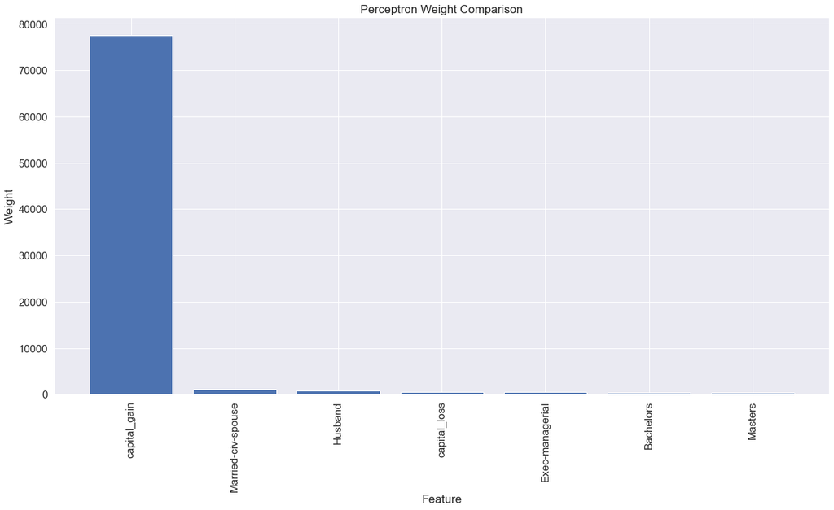

```python
plt.bar(pos_labels[:7], pos_corr[:7])
plt.xticks(rotation='vertical')
plt.ylabel('Weight')
plt.xlabel('Feature')
plt.title('Perceptron Weight Comparison')
```

From this, we can see that capital gain is by far the most important feature when determining if an individual makes over 50k per year. Intuitively, this makes sense as stock market gains are typically associated with wealthy individuals.

We will also plot the negative weights to show to most important features when determining if an individual does not make more than 50k.

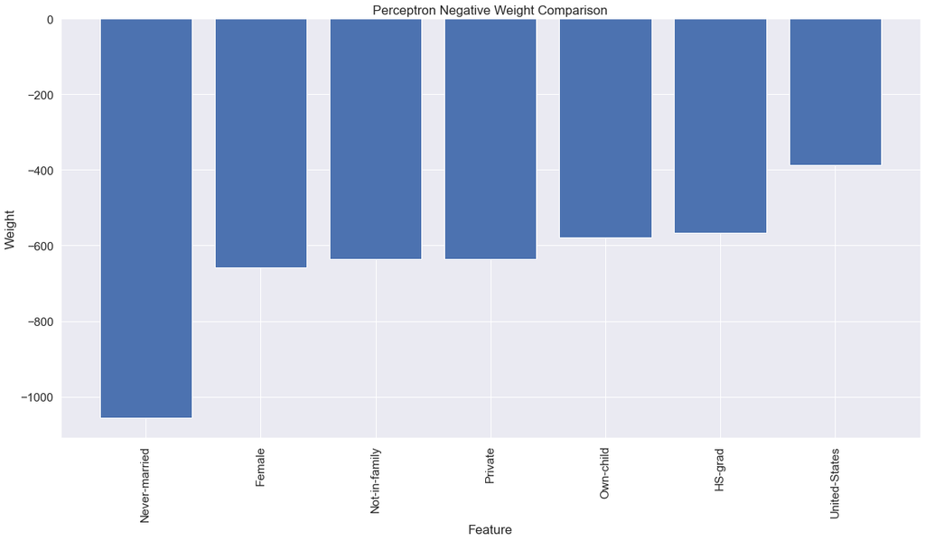

```python
plt.bar(neg_labels[:7], neg_corr[:7])
plt.xticks(rotation='vertical')
plt.xlabel('Feature')
plt.ylabel('Weight')
plt.title('Perceptron Negative Weight Comparison')
plt.show()
```

We will perform early stopping on the classifier while it is training to see how it affects the prediction rate, and determine if our model is overfitted.

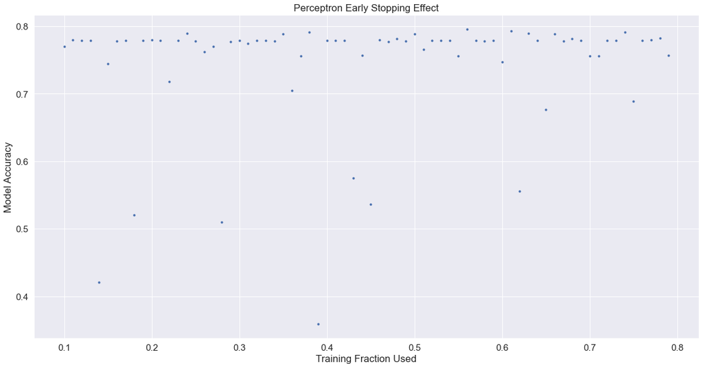

```python
early_stopping_fracs = []
for i in range(10,80):
    early_stopping_fracs.append(i / 100)


fractions_correct = []
for frac in early_stopping_fracs:
    early_train_x, early_test_x, early_train_y, early_test_y = train_test_split(train_x, train_y, test_size=(1-frac), shuffle=True)

    early_percep = Perceptron()
    for i in range(0, len(early_train_x)):
        early_percep.train_example(early_train_x[i], early_train_y[i])

    early_preds = []
    for i in range(0, len(test_x)):
        early_preds.append(-1 if early_percep.predict(test_x[i]) < 0 else 1)
    num_correct = sum(x == y for x,y in zip(test_y, early_preds))
    fractions_correct.append(num_correct / len(test_y))

plt.plot(early_stopping_fracs, fractions_correct, '.')
plt.xlabel('Training Fraction Used')
plt.ylabel('Model Accuracy')
plt.title('Perceptron Early Stopping Effect')
```

From this plot we can see that our original model was not overfitted, as the average prediction rate was around 0.7-0.8 with a few outliers.

## Accounting for bias in the dataset

Since ~85% of the data is made up of individuals whose race is "White", let's break down the classifiers into each respective race and re-run the classifiers to determine if race plays a role in the trends.

First, we'll separate the data based on race.

```python
race_dfs = []
for race in original_data['race'].unique():
    if race == 'White':
        # cut down data because it will be too much computation
        race_dfs.append(full_set[full_set[race] == 1].sample(frac=0.7))
    else:
        race_dfs.append(full_set[full_set[race] == 1])

for race in original_data['race'].unique():
    for i in range(0, len(race_dfs)):
        race_dfs[i] = race_dfs[i].drop(race, axis=1)
```

Now we can run the classifiers on each race and compare.

```python
race_x_data = []
race_y_data = []
for data in race_dfs:
    race_y_data.append(data['salary'].to_numpy())
    race_x_data.append(data.drop('salary', axis=1).to_numpy())
```

Separate into train/test sets

```python
training_x = []
training_y = []
test_x = []
test_y = []

for x,y in zip(race_x_data, race_y_data):
    temp_train_x, temp_test_x, temp_train_y, temp_test_y = train_test_split(x, y, test_size=0.2, shuffle=True)
    training_x.append(temp_train_x)
    test_x.append(temp_test_x)
    training_y.append(temp_train_y)
    test_y.append(temp_test_y)
```

## K-NN classifier

```python
race_accuracy = []
k = 3

for i in range(0, len(training_x)):
    preds = []
    for vec in test_x[i]:
        preds.append(knn_classify(k, training_x[i], training_y[i], vec, False))
    accuracy = sum(x == y for x,y in zip(test_y[i], preds)) / len(test_y[i])
    race_accuracy.append(accuracy)
```

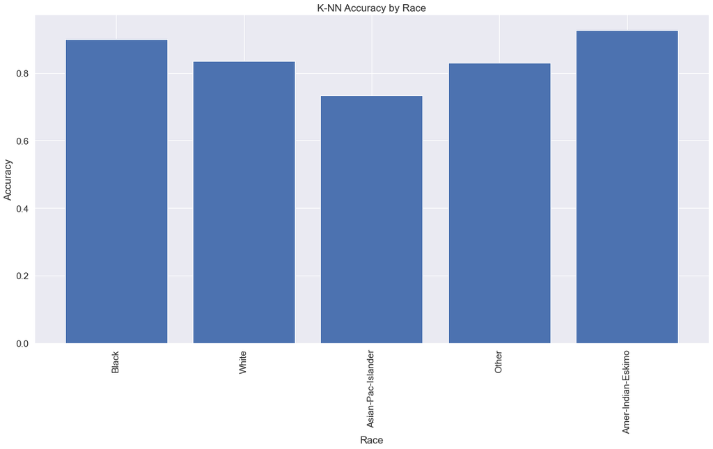

```python
plt.bar(original_data['race'].unique(), race_accuracy)
plt.xticks(rotation='vertical')
plt.xlabel('Race')
plt.ylabel('Accuracy')
plt.title('K-NN Accuracy by Race')
```

## Perceptron

We can also run the Perceptron classifier on the dataset for each race and compare the performance.

```python
percep_accuracy = []

for i in range(0, len(training_x)):
    percep = Perceptron()
    for j in range(0, len(training_x[i])):
        percep.train_example(training_x[i][j], training_y[i][j])

    preds = []
    for j in range(0, len(test_x[i])):
        preds.append(-1 if percep.predict(test_x[i][j]) < 0 else 1)

    accuracy = sum(x == y for x,y in zip(test_y[i], preds))
    percep_accuracy.append(accuracy / len(test_y[i]))
```

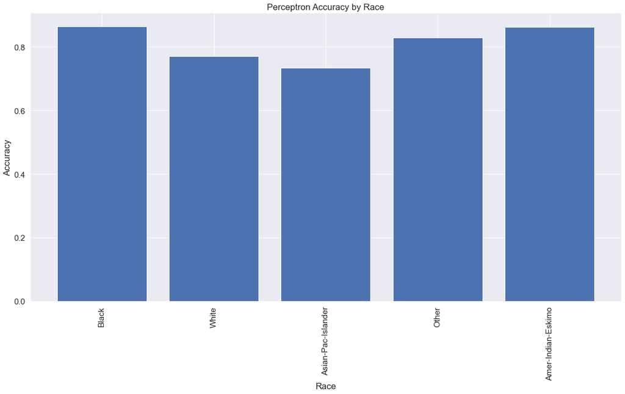

```python
plt.bar(original_data['race'].unique(), percep_accuracy)
plt.xticks(rotation='vertical')
plt.xlabel('Race')
plt.ylabel('Accuracy')
plt.title('Perceptron Accuracy by Race')
```

## Gradient Boosting

```python
df = pd.read_csv('Dataset.data', sep = ' ', header = None)
data = df.set_axis(['age', 'workclass', 'fnlwgt', 'highest_education', 'years_educated', 'marital_status', 'occupation','relationship', 'race', 'sex', 'capital_gain', 'capital_loss', 'hpw', 'native_country', 'salary'], axis=1)
original_data = data
```

```python
data
```

|  | age | workclass | fnlwgt | highest_education | years_educated | marital_status | occupation | relationship | race | sex | capital_gain | capital_loss | hpw | native_country | salary |
| --- | --- | --- | --- | --- | --- | --- | --- | --- | --- | --- | --- | --- | --- | --- | --- |
| 0 | 25 | Private | 226802 | 11th | 7 | Never-married | Machine-op-inspct | Own-child | Black | Male | 0 | 0 | 40 | United-States | <=50K |
| 1 | 38 | Private | 89814 | HS-grad | 9 | Married-civ-spouse | Farming-fishing | Husband | White | Male | 0 | 0 | 50 | United-States | <=50K |
| 2 | 28 | Local-gov | 336951 | Assoc-acdm | 12 | Married-civ-spouse | Protective-serv | Husband | White | Male | 0 | 0 | 40 | United-States | >50K |
| 3 | 44 | Private | 160323 | Some-college | 10 | Married-civ-spouse | Machine-op-inspct | Husband | Black | Male | 7688 | 0 | 40 | United-States | >50K |
| 4 | 18 | ? | 103497 | Some-college | 10 | Never-married | ? | Own-child | White | Female | 0 | 0 | 30 | United-States | <=50K |
| ... | ... | ... | ... | ... | ... | ... | ... | ... | ... | ... | ... | ... | ... | ... | ... |
| 48837 | 27 | Private | 257302 | Assoc-acdm | 12 | Married-civ-spouse | Tech-support | Wife | White | Female | 0 | 0 | 38 | United-States | <=50K |
| 48838 | 40 | Private | 154374 | HS-grad | 9 | Married-civ-spouse | Machine-op-inspct | Husband | White | Male | 0 | 0 | 40 | United-States | >50K |
| 48839 | 58 | Private | 151910 | HS-grad | 9 | Widowed | Adm-clerical | Unmarried | White | Female | 0 | 0 | 40 | United-States | <=50K |
| 48840 | 22 | Private | 201490 | HS-grad | 9 | Never-married | Adm-clerical | Own-child | White | Male | 0 | 0 | 20 | United-States | <=50K |
| 48841 | 52 | Self-emp-inc | 287927 | HS-grad | 9 | Married-civ-spouse | Exec-managerial | Wife | White | Female | 15024 | 0 | 40 | United-States | >50K |

48842 rows × 15 columns

## Preprocessing

```python
from sklearn.preprocessing import LabelEncoder, StandardScaler
```

### Combining similar data values

We see that there are many possible values for highest education among all of the induviduals in the sample. We will combine values that mean essentially the same thing since the abundence of values could effectively confuse our models, resulting in less accuracy. We will bucket "9th", "10th","11th" "12th", into "HS-no-grad", "5th-6th" and "7th-8th" into "Middle-school", "1st-4th" into "Elementary_school", "Prof-school" into "Doctorate", and finally "Assoc-acdm" and "Assoc-voc" into "Assoc".

```python
data.highest_education.unique()
```

```
array(['11th', 'HS-grad', 'Assoc-acdm', 'Some-college', '10th',
       'Prof-school', '7th-8th', 'Bachelors', 'Masters', 'Doctorate',
       '5th-6th', 'Assoc-voc', '9th', '12th', '1st-4th', 'Preschool'],
      dtype=object)
```

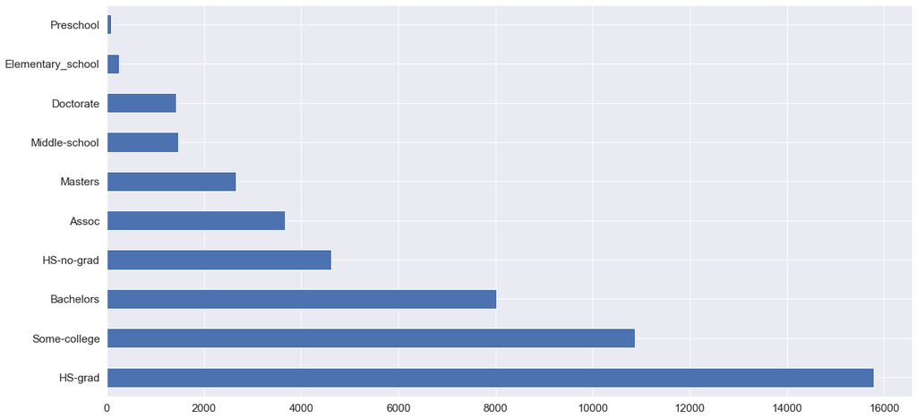

```python
data['highest_education'] = data['highest_education'].replace({'11th':'HS-no-grad','9th':'HS-no-grad','12th':'HS-no-grad',
                                               '10th':'HS-no-grad','7th-8th':'Middle-school',
                                               '5th-6th':'Middle-school','1st-4th':'Elementary_school',
                                               'Prof-school':'Doctorate','Assoc-acdm':'Assoc','Assoc-voc':'Assoc'})
data.highest_education.value_counts().plot(kind = 'barh')
```

Now we can see that we have less values possible for the highest education feature.

### Encoding

We also encode our qualitative data into numerical values for our models to be able to learn from all features.

```python
le = LabelEncoder()
data.columns
```

```
Index(['age', 'workclass', 'fnlwgt', 'highest_education', 'years_educated',
       'marital_status', 'occupation', 'relationship', 'race', 'sex',
       'capital_gain', 'capital_loss', 'hpw', 'native_country', 'salary'],
      dtype='object')
```

```python
data['workclass'] = le.fit_transform(data['workclass'])
data['highest_education'] = le.fit_transform(data['highest_education'])
data['marital_status'] = le.fit_transform(data['marital_status'])
data['occupation'] = le.fit_transform(data['occupation'])
data['relationship'] = le.fit_transform(data['relationship'])
data['race'] = le.fit_transform(data['race'])
data['sex'] = le.fit_transform(data['sex'])
data['native_country'] = le.fit_transform(data['native_country'])
```

### Mode of each attribute/replacing missing data:

We'll use the mode of each attribute to fill in the missing data points, currently represented by '?' in the dataset. The columns that are missing data are "workclass", "occupation", and "native-country". The modes of these 3 features are "Private", "Prof-speciality", and "United-States", respectively.

```python
data['workclass'] = data['workclass'].replace('?', 'Private')
data['occupation'] = data['occupation'].replace('?', 'Prof-specialty')
data['native_country'] = data['native_country'].replace('?', 'United-States')
```

### Set salary to be a binary variable

```python
data['salary'] = data['salary'].replace({'<=50K':0, '>50K':1})
```

### Observe the 5 characteristics with the top correlations to salary

```
[Text(0.5, 1.0, 'Top 5 Correlations Among Features')]
```

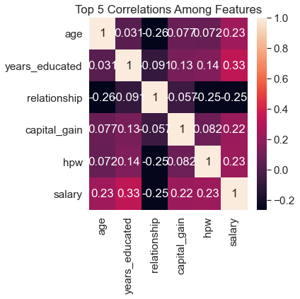

```python
data2 = data
data2 = data2.drop(['fnlwgt','workclass','highest_education','marital_status','occupation','race','sex','capital_loss','native_country'], axis=1)

fig, ax = plt.subplots(figsize=(5,5))
sns.heatmap(data2.corr(), annot=True, ax = ax).set(title = 'Top 5 Correlations Among Features')
```

### Reducing skew in the data

Before training any models on the dataset, we reduce the skew of certain variables that have a significant amount of skew. This will allow our classification models to learn more effectively.

Let's see how skewed the data is before we take any further action:

```python
data.skew()
```

```
age                   0.557580
workclass            -0.747910
fnlwgt                1.438892
highest_education     0.201952
years_educated       -0.316525
marital_status       -0.016328
occupation            0.110551
relationship          0.791719
race                 -2.447813
sex                  -0.715811
capital_gain         11.894659
capital_loss          4.569809
hpw                   0.238750
native_country       -3.689529
salary                1.222216
dtype: float64
```

We can see that capital gain and capital loss appear to have the most right skew out of any variables. Capital gain is also a highly correlated variable, it is important to reduce this skew so that our models are able to learn the data more easily and accurately. We will do so by using a cube root transformation. Capital gain will be reduced by exponentiating by the cube root twice, and capital loss will be reduced by exponentiating by the cube root once.

```python
data['capital_gain'] = (data['capital_gain'] ** (1/3)) ** (1/3)
data['capital_loss'] = data['capital_loss'] ** (1/3)
```

## Training a model

The model we will use to learn our data is the gradient boosting classifier.

```python
from sklearn.model_selection import train_test_split
from sklearn.metrics import accuracy_score, classification_report, confusion_matrix, plot_roc_curve
from sklearn.ensemble import GradientBoostingClassifier
from sklearn.model_selection import GridSearchCV
```

```python
y = data['salary']
x_data = data.drop('salary', axis = 'columns')
x = pd.DataFrame(x_data, columns = x_data.columns)
```

```python
x_train, x_test, y_train, y_test = train_test_split(x, y, test_size = 0.2, random_state = 20)

gb = GradientBoostingClassifier(random_state = 20)
gb.fit(x_train, y_train)
train_pred = gb.predict(x_train)
test_pred = gb.predict(x_test)
test_acc = accuracy_score(y_test, test_pred)
train_acc = accuracy_score(y_train, train_pred)
print(gb)
print("Training data accuracy ", accuracy_score(y_test, test_pred))
print("Test data accuracy ", accuracy_score(y_train, train_pred))
print(classification_report(y_test, test_pred))
print(confusion_matrix(y_test, test_pred))
print('###########################################')
```

```
GradientBoostingClassifier(random_state=20)
Training data accuracy  0.8624219469751254
Test data accuracy  0.8698333887850945
              precision    recall  f1-score   support

           0       0.88      0.95      0.91      7385
           1       0.79      0.60      0.68      2384

    accuracy                           0.86      9769
   macro avg       0.83      0.77      0.80      9769
weighted avg       0.86      0.86      0.86      9769

[[6998  387]
 [ 957 1427]]
###########################################
```

### ROC Curve

```
<sklearn.metrics._plot.roc_curve.RocCurveDisplay at 0x7f98a4407820>
```

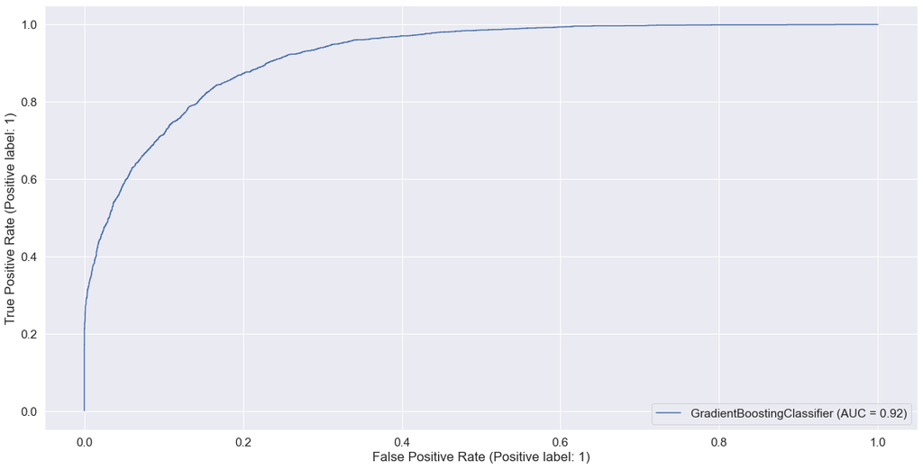

```python
plot_roc_curve(gb,x_test,y_test)
```

The ROC curve indicates a high level of seperability between or predicted variable "salary" as the area under the curve (AUC) is 0.92.

## Tuning Hyperparameters

The gradient boosting model allows us to tune parameters of 3 different categories. They are as follows:

- **Tree specific parameters**: modify induvidual trees generated in the model
- **Boosting parameters**: modify the boosting operations within the model
- **Miscellaneous**: modify the general function of the model, like the loss function

We will start by initializing some start values. They will be:

- **min_samples_split**: set equal to ~1% of total data points (490)
- **min_samples_leaf**: set to 50
- **max_depth**: set to 6
- **max_features**: set to 'sqrt'
- **subsample**: set to 0.8

Now we can start by determining an optimal number of estimators for the model. This value "n_estimators" dictates how many sequential trees will be modeled.

```python
x_train, x_test, y_train, y_test = train_test_split(x, y, test_size = 0.2)

test_est = {'n_estimators':range(220,501,10)}
gs = GridSearchCV(estimator = GradientBoostingClassifier(learning_rate=0.1, min_samples_split=490,min_samples_leaf=50,max_depth=6,max_features='sqrt',subsample=0.8,random_state=20),
param_grid = test_est, scoring='roc_auc',n_jobs=4, cv=5)
gs.fit(x_train, y_train)

gs.best_params_, gs.best_score_
```

```
({'n_estimators': 340}, 0.9268035216965409)
```

```python
test_ds = {'max_depth':range(5,9,1), 'min_samples_split':range(400,701,100)}
gs = GridSearchCV(estimator = GradientBoostingClassifier(learning_rate=0.1, n_estimators=320, min_samples_split=490,min_samples_leaf=50,max_depth=6,max_features='sqrt',subsample=0.8,random_state=20),
param_grid = test_ds, scoring='roc_auc',n_jobs=4, cv=5)
gs.fit(x_train, y_train)

gs.best_params_, gs.best_score_
```

```
({'max_depth': 6, 'min_samples_split': 600}, 0.9268873628896133)
```

```python
test_ds = {'min_samples_leaf':range(30,51,10)}
gs = GridSearchCV(estimator = GradientBoostingClassifier(learning_rate=0.1, n_estimators=320, min_samples_split=600,min_samples_leaf=50,max_depth=7,max_features='sqrt',subsample=0.8,random_state=20),
param_grid = test_ds, scoring='roc_auc',n_jobs=4, cv=5)
gs.fit(x_train, y_train)

gs.best_params_, gs.best_score_
```

```
({'min_samples_leaf': 50}, 0.9265009659270451)
```

### Update all the hyperparameters, and re-run the model

```python
x_train, x_test, y_train, y_test = train_test_split(x, y, test_size = 0.2, random_state = 20)

gb = GradientBoostingClassifier(learning_rate=0.1, n_estimators=320, min_samples_split=600,min_samples_leaf=40,max_depth=7,max_features='sqrt',subsample=0.8,random_state=20)
gb.fit(x_train, y_train)
train_pred = gb.predict(x_train)
test_pred = gb.predict(x_test)
test_acc = accuracy_score(y_test, test_pred)
train_acc = accuracy_score(y_train, train_pred)
print(gb)
print("Training data accuracy ", accuracy_score(y_test, test_pred))
print("Test data accuracy ", accuracy_score(y_train, train_pred))
print(classification_report(y_test, test_pred))
print(confusion_matrix(y_test, test_pred))
print('###########################################')
```

```
GradientBoostingClassifier(max_depth=7, max_features='sqrt',
                           min_samples_leaf=40, min_samples_split=600,
                           n_estimators=320, random_state=20, subsample=0.8)
Training data accuracy  0.8691780120790255
Test data accuracy  0.8910500857369539
              precision    recall  f1-score   support

           0       0.89      0.94      0.92      7385
           1       0.77      0.66      0.71      2384

    accuracy                           0.87      9769
   macro avg       0.83      0.80      0.81      9769
weighted avg       0.86      0.87      0.87      9769

[[6925  460]
 [ 818 1566]]
###########################################
```

## Plotting accuracy of Features with Low Diversity Individually

```python
def plotAccuracyforFeature(feature, model):
    feature_dfs = {}
    for feat in original_data[feature].unique():
        feature_dfs[feat] = (original_data.loc[original_data[feature] == feat])

    for feat in feature_dfs.keys():
        feature_dfs[feat]['workclass'] = le.fit_transform(feature_dfs[feat]['workclass'])
        feature_dfs[feat]['highest_education'] = le.fit_transform(feature_dfs[feat]['highest_education'])
        feature_dfs[feat]['marital_status'] = le.fit_transform(feature_dfs[feat]['marital_status'])
        feature_dfs[feat]['occupation'] = le.fit_transform(feature_dfs[feat]['occupation'])
        feature_dfs[feat]['relationship'] = le.fit_transform(feature_dfs[feat]['relationship'])
        feature_dfs[feat]['sex'] = le.fit_transform(feature_dfs[feat]['sex'])
        feature_dfs[feat]['race'] = le.fit_transform(feature_dfs[feat]['race'])
        feature_dfs[feat]['native_country'] = le.fit_transform(feature_dfs[feat]['native_country'])

        feature_dfs[feat] = feature_dfs[feat].drop(feature, axis=1)


    accuracy = {}
    for feat in feature_dfs.keys():
        sc = StandardScaler()
        data_x = feature_dfs[feat].drop('salary', axis = 'columns')

        y = feature_dfs[feat]['salary']

        scaled_data_x = sc.fit_transform(data_x)
        x = pd.DataFrame(scaled_data_x, columns = data_x.columns)


        if x.shape[0] == 1:
            X_train = X_test = x
            y_train = y_test = y
        else:
            X_train, X_test, y_train, y_test = train_test_split(x, y, test_size=0.20, random_state=20)

        gb = GradientBoostingClassifier(learning_rate=0.1, n_estimators=320, min_samples_split=600,min_samples_leaf=40,max_depth=7,max_features='sqrt',subsample=0.8,random_state=20)
        gb = gb.fit(X_train, y_train)

        train_pred = gb.predict(X_train)
        test_pred = gb.predict(X_test)
        test_acc = accuracy_score(y_test, test_pred)
        train_acc = accuracy_score(y_train, train_pred)

        accuracy[feat] = {'trainAcc': float(train_acc), 'testAcc': float(test_acc)}


    feat_accuracy_df = []
    for key in accuracy.keys():
        tmp = [key, accuracy[key]['trainAcc'],accuracy[key]['testAcc']]
        feat_accuracy_df.append(tmp)

    feat_accuracy_df = np.array(feat_accuracy_df)
    feat_accuracy_df = pd.DataFrame(feat_accuracy_df, columns=[feature,'TrainAccuracy','TestAccuracy'])
    feat_accuracy_df['TrainAccuracy'] = feat_accuracy_df['TrainAccuracy'].astype(float)
    feat_accuracy_df['TestAccuracy'] = feat_accuracy_df['TestAccuracy'].astype(float)
    #race_accuracy_df

    X_axis = np.arange(len(feat_accuracy_df[feature]))
    plt.rcParams["figure.figsize"] = (20,10)
    bar1 = plt.bar(X_axis, (feat_accuracy_df['TrainAccuracy']), width=0.50, color='b', align='center')
    bar2 = plt.bar(X_axis+0.4, (feat_accuracy_df['TestAccuracy']), width=0.50, color='g', align='center')

    plt.xticks(X_axis, feat_accuracy_df[feature])
    plt.xlabel(feature)
    plt.ylabel('Accuracy')
    plt.title("{featName} Vs Accuracy on {modelName}".format(featName=feature, modelName=model))
    plt.legend( (bar1, bar2), ('Training Accuracy', 'Test Accuracy') )

    if len(feat_accuracy_df[feature]) >= 10:
        plt.xticks(rotation=90)

    plt.show()
```

### Sex vs. Accuracy

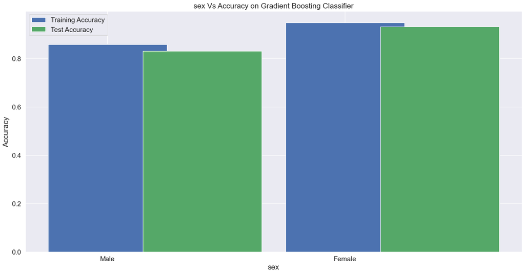

```python
plotAccuracyforFeature('sex','Gradient Boosting Classifier')
```

### Race vs. Accuracy

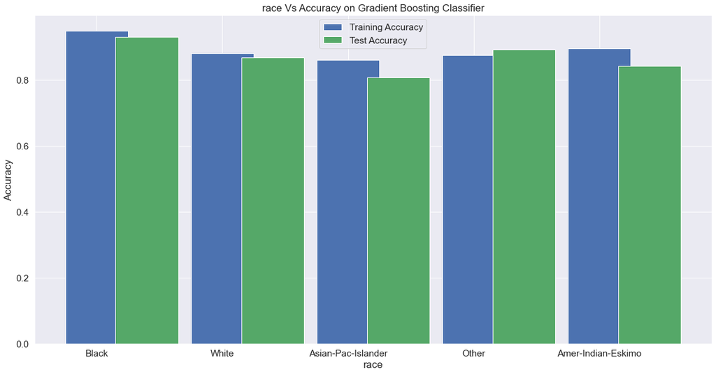

```python
plotAccuracyforFeature('race','Gradient Boosting Classifier')
```